# LAB 44-A (MD)

AnaGSanjuanM

2023-03-10

—————————LABORATORIO 44-A————————

———-ACADÉMICO: CARLA CAROLINA PÉREZ HERNÁNDEZ—————-

—————ALUMNA: ANA GRISEL SANJUAN MERIDA——————-

——————A tale of two heatmap functions——————

https://divingintogeneticsandgenomics.rbind.io/post/a-tale-of-two-heatmap-functions/

Se instala la paquetería

install.packages(“gplots”)

install.packages(“heatmaps”)

install.packages(“pheatmaps”)

Se cargan las librerías

```r
library(stats)
library(gplots)
```

Medida de la expresión génica de 4 genes (h1, h2, l1 y l2) en 8 puntos de tiempo

```r
h1 <- c(10,20,10,20,10,20,10,20)
h2 <- c(20,10,20,10,20,10,20,10)
l1 <- c(1,3,1,3,1,3,1,3)
l2 <- c(3,1,3,1,3,1,3,1)
```

Generamos matriz denominada mat para enlazar los genes

```r
mat <- rbind(h1,h2,l1,l2)
```

Se corren los siguientes comandos para generar el plot

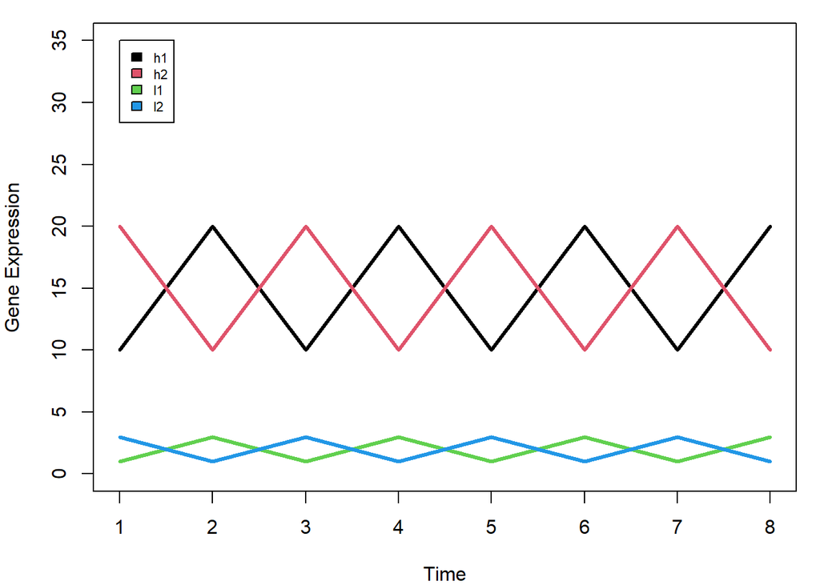

```r
par(mfrow =c(1,1), mar=c(4,4,1,1))
plot(1:8,rep(0,8), ylim=c(0,35), pch="", xlab="Time", ylab="Gene Expression")

for (i in 1:nrow(mat)) {
  lines(1:8,mat[i,], lwd=3, col=i)
}

legend(1,35,rownames(mat), 1:4, cex=0.7)
```

Para calcular la distancia

```r
dist(mat)
```

```
##           h1        h2        l1
## h2 28.284271
## l1 38.470768 40.496913
## l2 40.496913 38.470768  5.656854
```

Se usa el método predeterminado para el enlace: completo

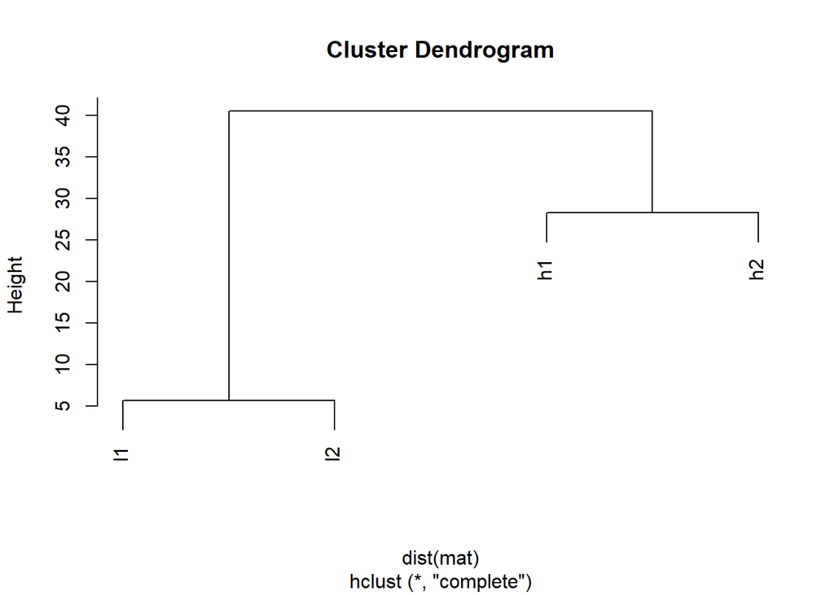

```r
plot(hclust(dist(mat)))
```

Headmap predeterminado, para obtener explicitamente parámetros

Escala en los renglones con escala de color verde y roja

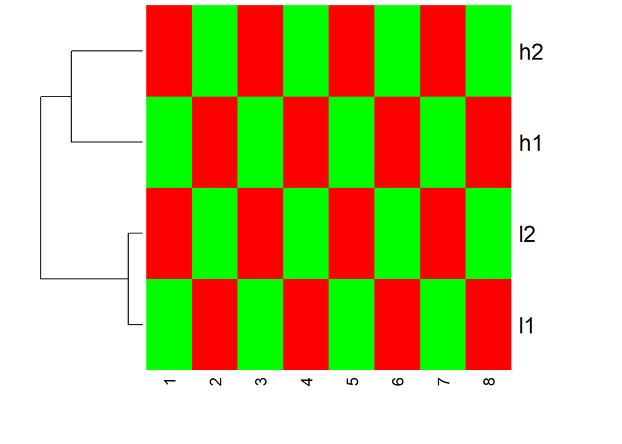

```r
heatmap(mat, Colv=NA, col=greenred(10), scale = "row")
```

Heatmap con la escala desactivada

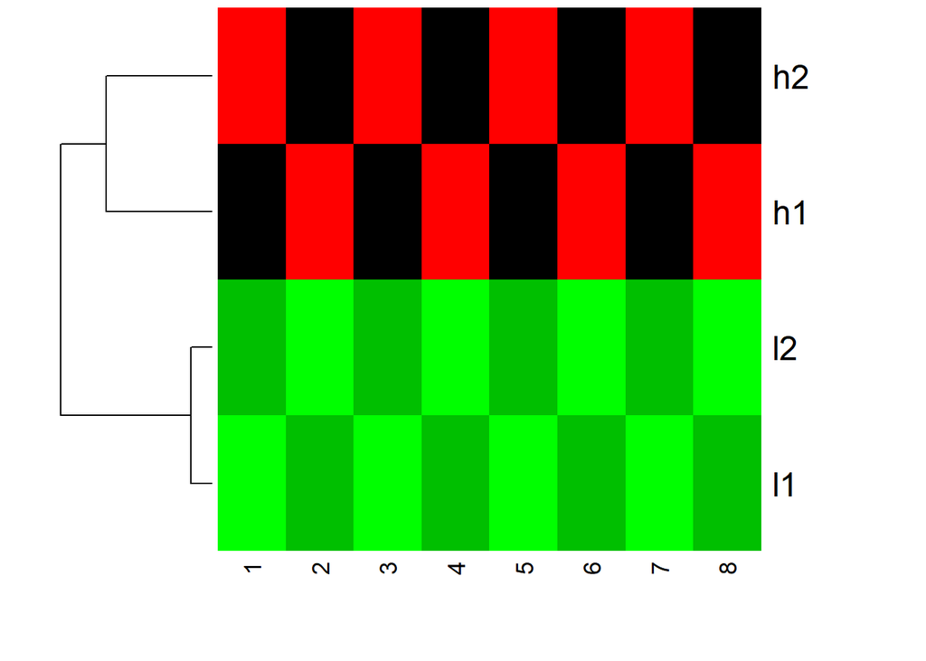

```r
heatmap(mat, Colv = NA, col=greenred(10), scale = "none")
```

Escalando los genes antes de introducirlos al heatmap

```r
mat.scaled<- t(scale(t(mat), center=TRUE, scale = TRUE))
mat.scaled
```

```
##          [,1]       [,2]       [,3]       [,4]       [,5]       [,6]       [,7]
## h1 -0.9354143  0.9354143 -0.9354143  0.9354143 -0.9354143  0.9354143 -0.9354143
## h2  0.9354143 -0.9354143  0.9354143 -0.9354143  0.9354143 -0.9354143  0.9354143
## l1 -0.9354143  0.9354143 -0.9354143  0.9354143 -0.9354143  0.9354143 -0.9354143
## l2  0.9354143 -0.9354143  0.9354143 -0.9354143  0.9354143 -0.9354143  0.9354143
##          [,8]
## h1  0.9354143
## h2 -0.9354143
## l1  0.9354143
## l2 -0.9354143
## attr(,"scaled:center")
## h1 h2 l1 l2
## 15 15  2  2
## attr(,"scaled:scale")
##       h1       h2       l1       l2
## 5.345225 5.345225 1.069045 1.069045
```

Cambio e la distancia entre genes

```r
dist(mat.scaled)
```

```
##          h1       h2       l1
## h2 5.291503
## l1 0.000000 5.291503
## l2 5.291503 0.000000 5.291503
```

Obtener el plot

Ahora h1 y l1 están agrupados juntos; l2 y h2 están agrupados juntos

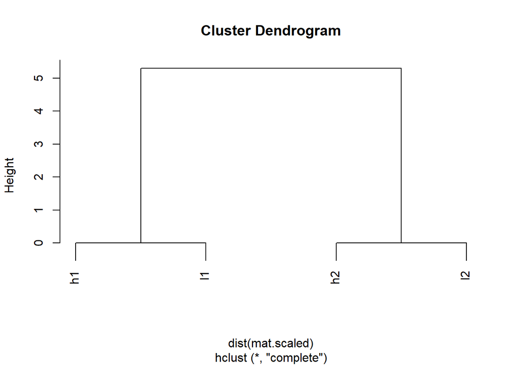

```r
plot(hclust(dist(mat.scaled)))
```

Generando el heatmap

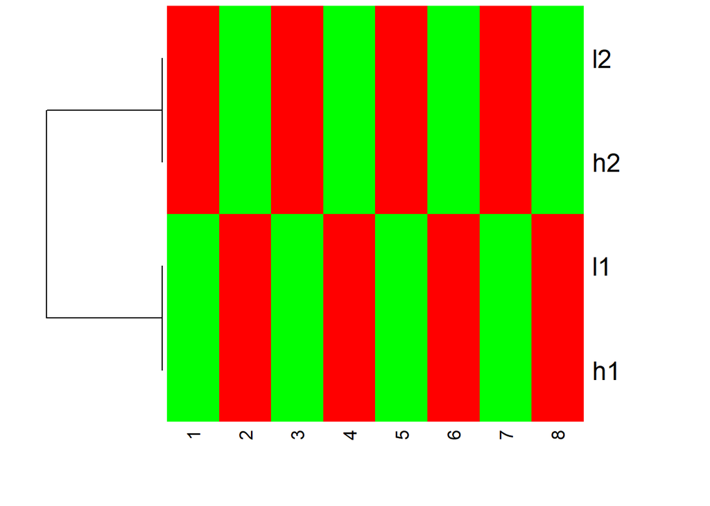

```r
heatmap(mat.scaled, Colv = NA, col=greenred(10), scale = "none")
```

Si aún no se escalan los datos pero se desea que l1 y h1 se agrupen juntos, al igual que l2 y h2, se puede usar la medida de distancia diferentes

Correlación entre genes para asignar valores de 1 y -1

```r
cor(t(mat))
```

```
##    h1 h2 l1 l2
## h1  1 -1  1 -1
## h2 -1  1 -1  1
## l1  1 -1  1 -1
## l2 -1  1 -1  1
```

Correlación para definir la distancia

```r
1- cor(t(mat))
```

```
##    h1 h2 l1 l2
## h1  0  2  0  2
## h2  2  0  2  0
## l1  0  2  0  2
## l2  2  0  2  0
```

Generamos el dendrograma

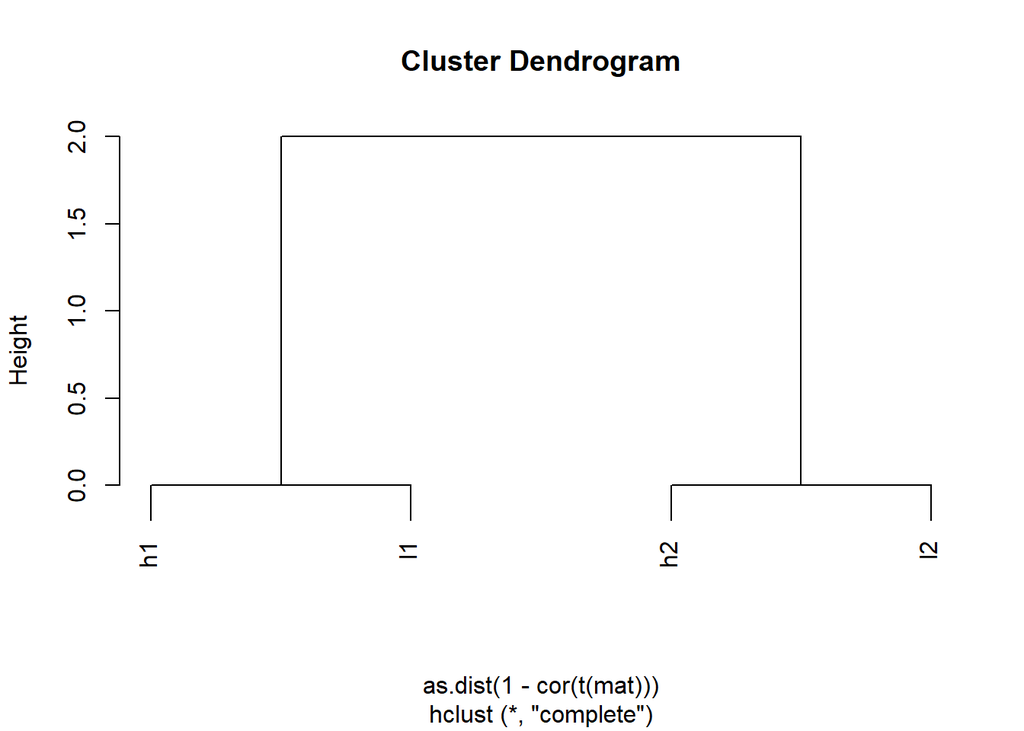

```r
hc <- hclust(as.dist(1-cor(t(mat))))
plot(hc)
```

Heatmap sin escala

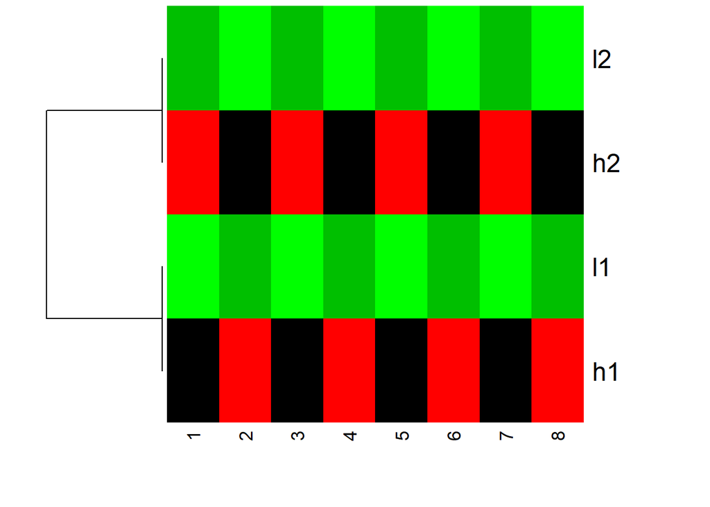

```r
heatmap(mat, Colv = NA, Rowv=as.dendrogram(hc), col=greenred(10), scale = "none")
```

Heatmap con la escala en los renglones

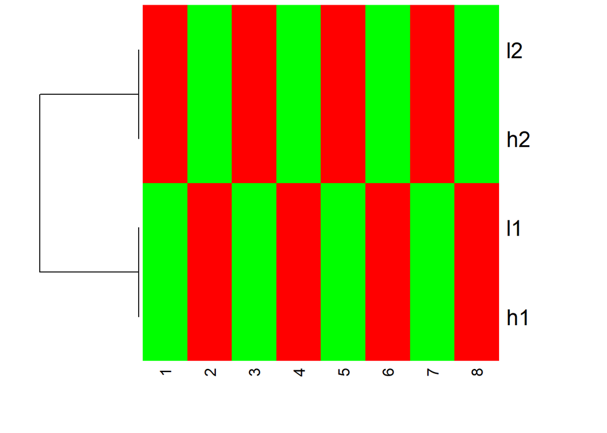

```r
heatmap(mat, Colv = NA, Rowv=as.dendrogram(hc), col=greenred(10), scale = "row")
```

Valores predeterminados de heatmap.2 con ninguna escala

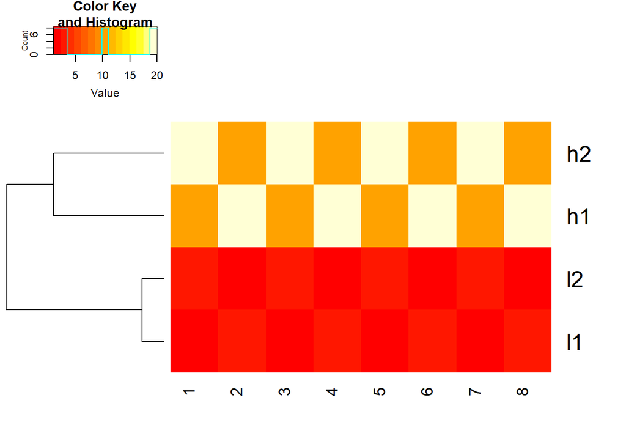

```r
heatmap.2(mat, trace = "none", Colv= NA, dendrogram = "row", scale = "none")
```

Funciones de heatmap en R: primero se agrupa y luego usa el argumento de escala (si está configurado) para representar los datos

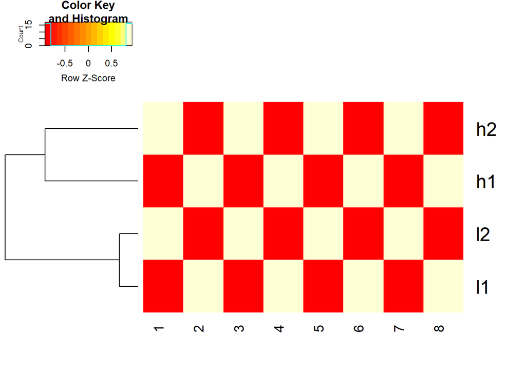

```r
heatmap.2(mat, trace = "none", Colv= NA, dendrogram = "row", scale = "row")
```

Datos escalados explícitamente primero y uso de la distancia euclidiana

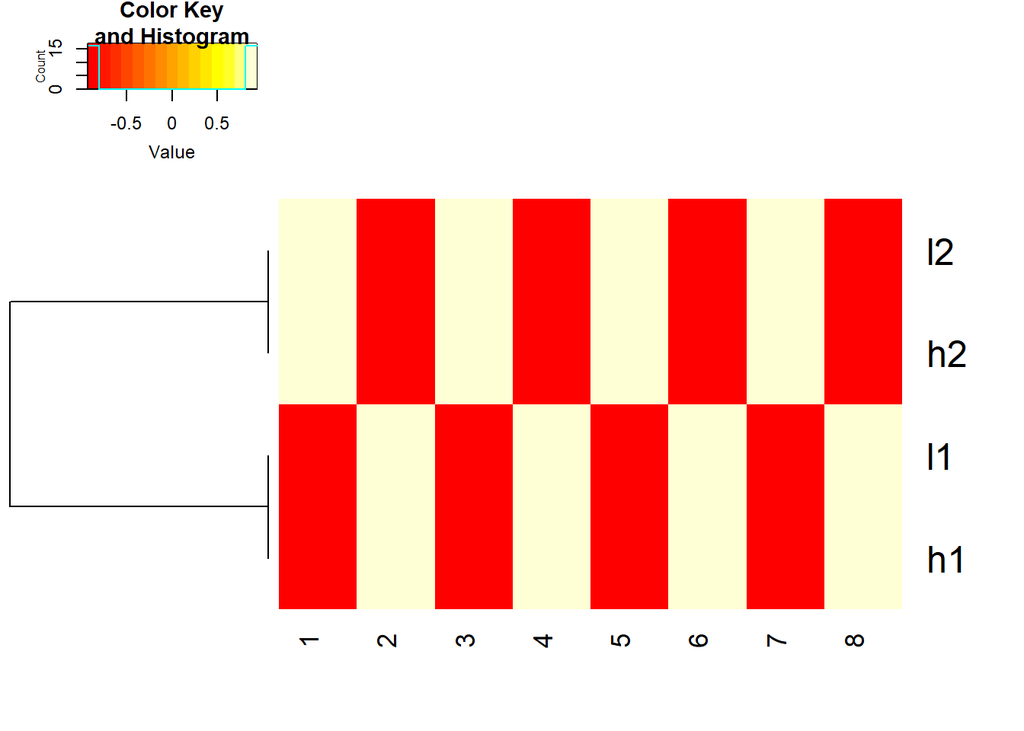

```r
heatmap.2(t(scale(t(mat), center=TRUE, scale=TRUE)), trace = "none", Colv= NA, dendrogram = "row", scale = "none")
```

Usando 1- cor(x) como distancia y no escalar

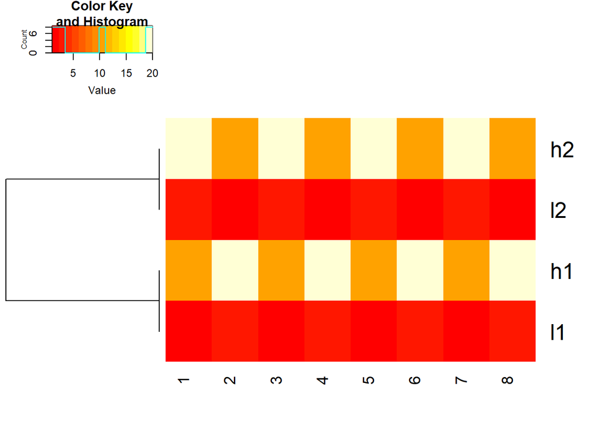

```r
heatmap.2(mat, trace = "none",
          Colv= NA, dendrogram = "row",
          scale = "none",
          hclust=function(x) hclust(x, method='complete'), distfun=function(x) as.dist(1-cor(t(x))))
```

Usar la escala en la función heatmap.2 para representar los colores

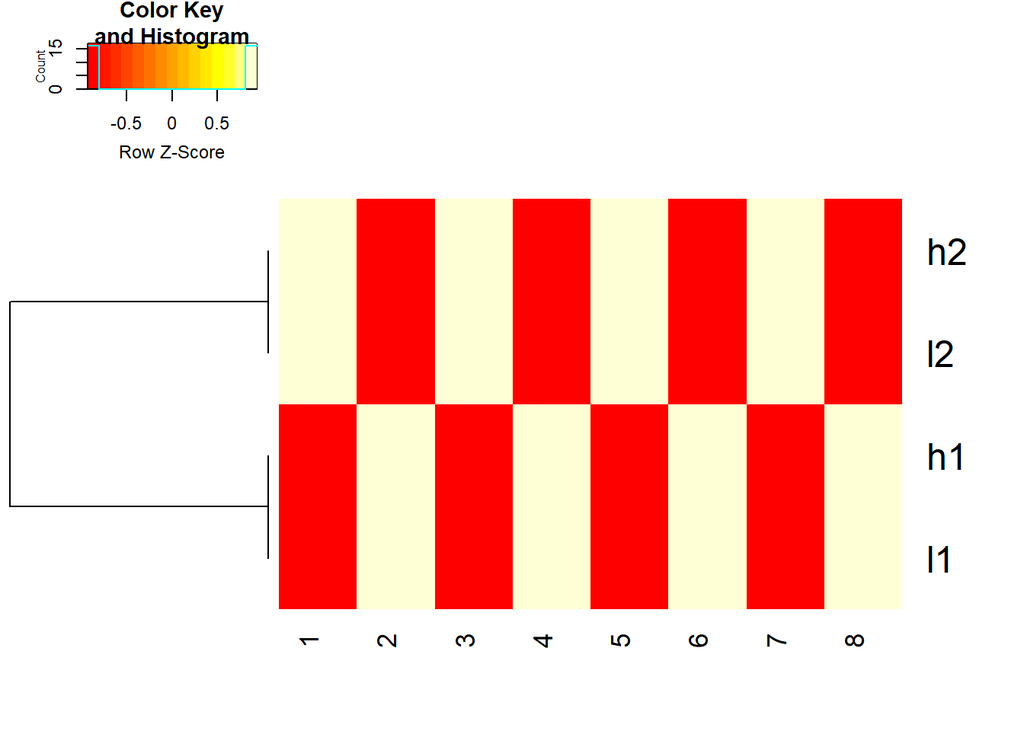

```r
heatmap.2(mat, trace = "none",
          Colv= NA, dendrogram = "row",
          scale = "row",
          hclust=function(x) hclust(x, method='complete'), distfun=function(x) as.dist(1-cor(t(x))))
```

Escala y uso de 1- cor(x) como distancia

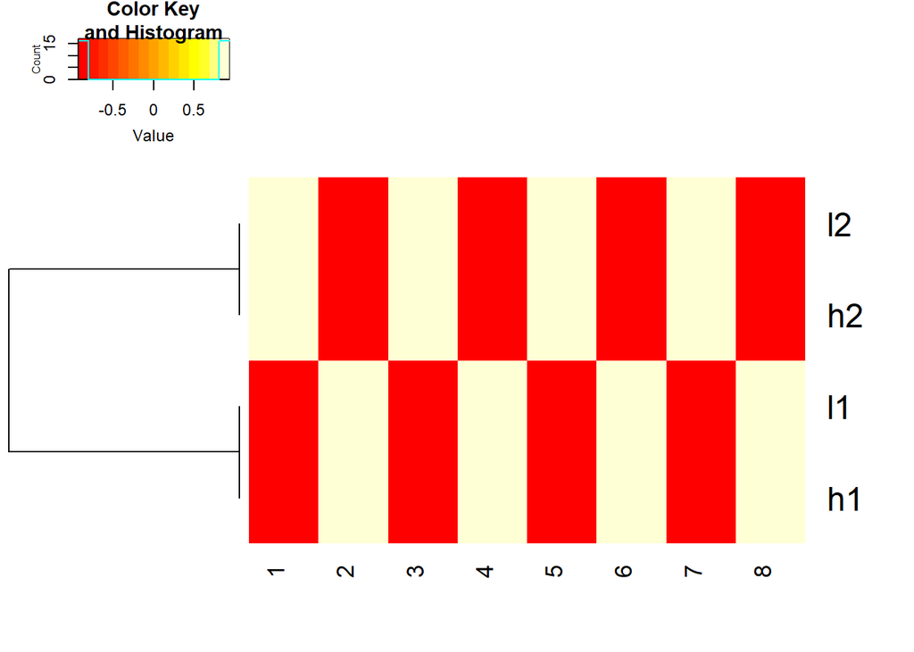

```r
heatmap.2(t(scale(t(mat), center=TRUE, scale=TRUE)), trace = "none",
          Colv= NA, dendrogram = "row",
          hclust=function(x) hclust(x, method='complete'), distfun=function(x) as.dist(1-cor(t(x))))
```

—————————–FIN DE LABORATORIO 44-A———————————-